# Notebook

**Research Question:** "Which treatments have the best outcomes in Long COVID?"

## 1. Data Exploration

Data covers: **2026-03-11 to 2026-04-10 (~1 month)** from r/covidlonghaulers.

| Metric | Count |
| --- | --- |
| Total users | 2,827 |
| Users with treatment reports | 1,121 |
| Total treatment reports | 6,815 |
| Unique drug names | 1,257 |
| Posts | 17,182 |

**Sentiment distribution across all reports:** 67% positive, 24% negative, 9% mixed, <1% neutral. This community skews positive in its reporting -- people tend to share what works more than what fails, a selection bias we must keep in mind.

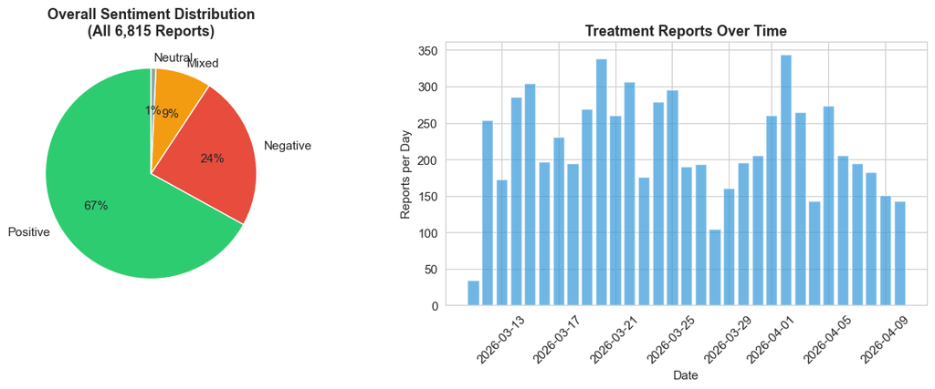

The left panel shows the overall sentiment skew: two-thirds of reports are positive, reflecting the community's tendency to share successful treatments. The right panel shows reporting is roughly uniform across the month, with no major spikes that would bias time-specific treatments.

## 2. Treatment Ranking by Community Outcome

Before testing specific hypotheses, we need a reliable ranking. Raw positive percentages are misleading when sample sizes vary widely (n=183 for LDN vs n=20 for gabapentin). We rank by **Wilson score lower bound** -- the lower edge of the 95% confidence interval for the positive rate. This penalizes treatments with few reporters, surfacing only those with both high rates *and* adequate evidence.

All analysis is at the **user level**: each person counts once per treatment, based on their average sentiment score across all their reports for that treatment. A user is "positive" if their average score > 0.

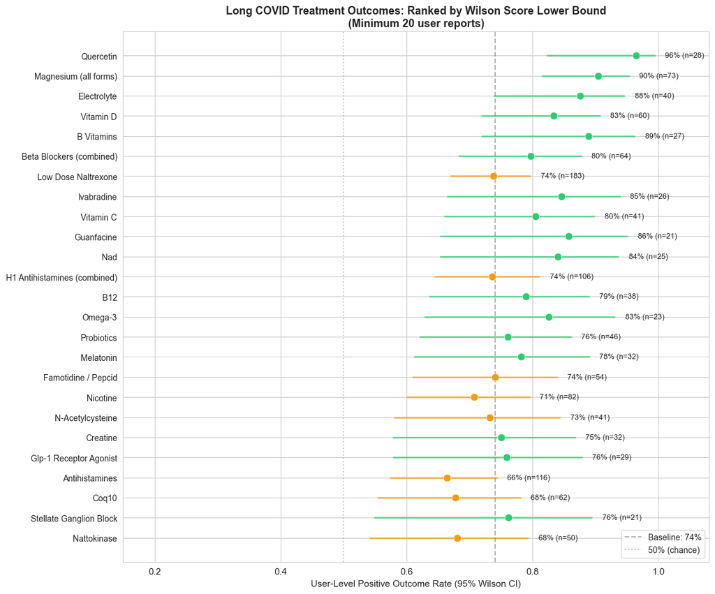

**How to read this chart:** Each dot shows the percentage of users who reported a positive outcome for that treatment. The horizontal line is the 95% confidence interval -- wider lines mean less certainty. Treatments are ranked by the lower bound of this interval (the worst plausible positive rate), so treatments at the top have both high positive rates *and* enough data to be confident.

The baseline positive rate across all treatments is 74% -- meaning the average treatment in this community is reported positively. This reflects reporting bias (people share successes more) and should not be interpreted as "74% of treatments work."

## 3. Statistical Comparisons: What Stands Out?

The forest plot shows a clear spread, but visual differences can be misleading. This section tests whether the top and bottom performers are statistically different from the population baseline, and from each other.

Binomial Test: Each Treatment vs. 50% Chance Baseline

| Treatment | n | Positive Rate | p vs 50% | Cohen's h | 95% CI | NNT vs Baseline |
| --- | --- | --- | --- | --- | --- | --- |
| Quercetin | 28 | 96% | < 0.001 *** | 1.19 | [82%, 99%] | 4.5 |
| Magnesium (all forms) | 73 | 90% | < 0.001 *** | 0.94 | [82%, 95%] | 6.1 |
| Electrolyte | 40 | 88% | < 0.001 *** | 0.85 | [74%, 95%] | 7.5 |
| Vitamin D | 60 | 83% | < 0.001 *** | 0.73 | [72%, 91%] | 10.8 |
| B Vitamins | 27 | 89% | < 0.001 *** | 0.89 | [72%, 96%] | 6.8 |
| Beta Blockers (combined) | 64 | 80% | < 0.001 *** | 0.64 | [68%, 88%] | 17.8 |
| Low Dose Naltrexone | 183 | 74% | < 0.001 *** | 0.50 | [67%, 80%] | — |
| Ivabradine | 26 | 85% | < 0.001 *** | 0.76 | [66%, 94%] | 9.5 |
| Vitamin C | 41 | 80% | < 0.001 *** | 0.66 | [66%, 90%] | 15.6 |
| Guanfacine | 21 | 86% | 0.001 ** | 0.80 | [65%, 95%] | 8.6 |
| Nad | 25 | 84% | < 0.001 *** | 0.75 | [65%, 94%] | 10.1 |
| H1 Antihistamines (combined) | 106 | 74% | < 0.001 *** | 0.49 | [64%, 81%] | — |
| B12 | 38 | 79% | < 0.001 *** | 0.62 | [64%, 89%] | 20.5 |
| Omega-3 | 23 | 83% | 0.003 ** | 0.71 | [63%, 93%] | 11.7 |
| Probiotics | 46 | 76% | < 0.001 *** | 0.55 | [62%, 86%] | 49.8 |
| Melatonin | 32 | 78% | 0.002 ** | 0.60 | [61%, 89%] | 24.7 |
| Famotidine / Pepcid | 54 | 74% | < 0.001 *** | 0.50 | [61%, 84%] | — |
| Nicotine | 82 | 71% | < 0.001 *** | 0.43 | [60%, 79%] | — |
| N-Acetylcysteine | 41 | 73% | 0.004 ** | 0.48 | [58%, 84%] | — |
| Creatine | 32 | 75% | 0.007 ** | 0.52 | [58%, 87%] | 108.7 |
| Glp-1 Receptor Agonist | 29 | 76% | 0.008 ** | 0.54 | [58%, 88%] | 56.1 |
| Antihistamines | 116 | 66% | < 0.001 *** | 0.33 | [57%, 74%] | — |
| Coq10 | 62 | 68% | 0.007 ** | 0.36 | [55%, 78%] | — |
| Stellate Ganglion Block | 21 | 76% | 0.027 * | 0.55 | [55%, 89%] | 47.4 |
| Nattokinase | 50 | 68% | 0.015 * | 0.37 | [54%, 79%] | — |
| Antivirals / Paxlovid | 42 | 69% | 0.020 * | 0.39 | [54%, 81%] | — |
| Tirzepatide | 24 | 71% | 0.064 | 0.43 | [51%, 85%] | — |
| Peptide | 26 | 69% | 0.076 | 0.39 | [50%, 83%] | — |
| Red Light Therapy | 21 | 67% | 0.189 | 0.34 | [45%, 83%] | — |
| Zepbound | 25 | 64% | 0.230 | 0.28 | [45%, 80%] | — |
| Vagus Nerve Stimulation | 20 | 65% | 0.263 | 0.30 | [43%, 82%] | — |
| Taurine | 20 | 65% | 0.263 | 0.30 | [43%, 82%] | — |
| Steroids | 20 | 65% | 0.263 | 0.30 | [43%, 82%] | — |
| H2 Antihistamine | 28 | 61% | 0.345 | 0.22 | [42%, 76%] | — |
| SSRIs / Antidepressants (combined) | 82 | 52% | 0.741 | 0.05 | [42%, 63%] | — |
| Antibiotics | 34 | 47% | 0.864 | -0.06 | [31%, 63%] | — |
| Gabapentin | 20 | 45% | 0.824 | -0.10 | [26%, 66%] | — |
| Cromolyn Sodium | 23 | 35% | 0.210 | -0.31 | [19%, 55%] | — |

*** p<0.001, ** p<0.01, * p<0.05. Cohen's h: small=0.2, medium=0.5, large=0.8. NNT = number needed to treat vs population baseline (74%).

Head-to-Head: Top 5 vs Bottom 5 Treatments

| **Top 5** (Quercetin, Magnesium (all forms), Electrolyte, Vitamin D, B Vitamins) | 89% positive (n=228) |
| --- | --- |
| **Bottom 5** (H2 Antihistamine, SSRIs / Antidepressants (combined), Antibiotics, Gabapentin, Cromolyn Sodium) | 50% positive (n=187) |
| **Fisher's exact test:** OR = 7.85, p < 0.001 |  |
| **Cohen's h:** 0.89 (large effect) |  |
| **Plain language:** Users trying top-performing treatments are roughly 7.9x as likely to report a positive outcome compared to the bottom performers. |  |

## 4. Sentiment Breakdown by Treatment

The previous section looked at binary outcomes (positive vs not). But "not positive" is not a single thing -- a treatment that produces 40% positive and 50% mixed is different from one that produces 40% positive and 50% negative. This diverging bar chart shows the full sentiment breakdown.

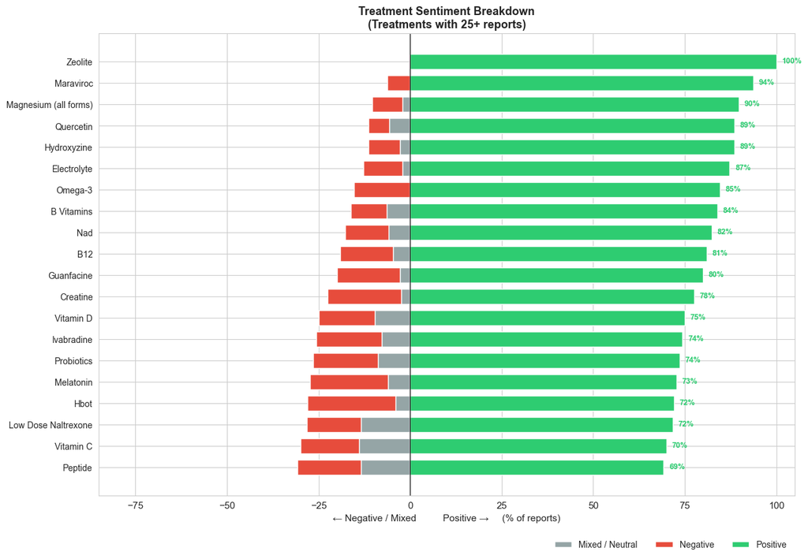

## 5. Does the Best Treatment Depend on Your Condition?

Long COVID is not one disease. Users with POTS (postural orthostatic tachycardia syndrome), MCAS (mast cell activation syndrome), ME/CFS (myalgic encephalomyelitis / chronic fatigue syndrome), or PEM (post-exertional malaise) may respond differently to the same treatment. This heatmap shows positive outcome rates for top treatments stratified by the user's reported co-occurring condition.

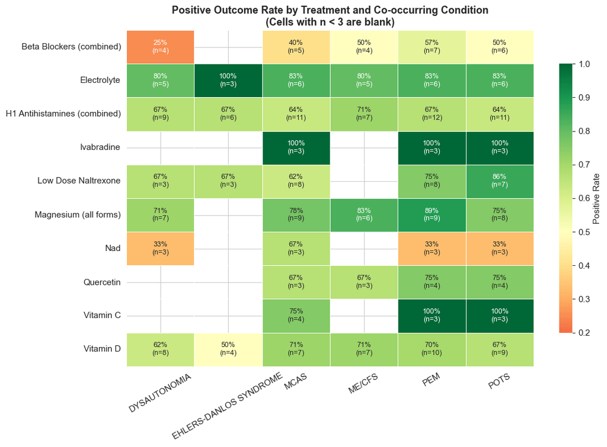

**How to read this heatmap:** Green cells indicate high positive outcome rates; red/yellow indicates low. The sample size in each cell (n=X) shows how many users reported on that treatment while also having that condition. Blank cells mean fewer than 3 users overlap -- too few to display.

**Key patterns to note:** Treatments like LDN and magnesium maintain high positive rates across most conditions. But some treatments show condition-specific patterns that merit further investigation -- for example, whether beta blockers perform better among POTS patients (where they have a clear physiological rationale) versus ME/CFS patients (where they may be less relevant).

Note that these cross-tabulations have small cell sizes. Treat condition-specific patterns as hypotheses, not conclusions.

## 6. Counterintuitive Findings Worth Investigating

This section flags results that contradict clinical guidelines, community assumptions, or common sense. These are not conclusions -- they are patterns worth investigating further.

Finding 2: SSRIs Are the Most Polarizing Treatment Class

SSRIs (combined with fluvoxamine, sertraline, duloxetine, and generic antidepressant mentions) show a **52%** positive rate (n=82). This is essentially a coin flip. Yet fluvoxamine specifically has been studied in clinical trials for Long COVID. When isolated, fluvoxamine alone shows 46% positive (n=24), which is similarly poor. The community's experience with SSRIs is notably worse than the clinical research would suggest.

Finding 3: Nicotine Patches -- An Unconventional Treatment That Outperforms

Nicotine (primarily patches) achieves **71%** positive outcomes from 82 users. For a substance most associated with addiction, this is a surprisingly strong showing. The r/covidlonghaulers community has championed nicotine patches based on the nicotinic acetylcholine receptor hypothesis. This data suggests the community's enthusiasm has some empirical backing in reported outcomes -- though these are self-reports, not clinical measurements.

Finding 4: Micronutrients Outperform Prescription Medications

When grouped into categories, over-the-counter micronutrients (magnesium, B vitamins, CoQ10, electrolytes, etc.) achieve **82%** positive outcomes (n=444) versus **66%** for prescription medications (SSRIs, beta blockers, gabapentin, etc., n=352). Fisher's exact: OR=2.29, p < 0.001, Cohen's h=0.36. This does not mean supplements are "better" -- it likely reflects that micronutrient deficiencies are common in Long COVID and easier to correct, while prescriptions target more complex pathology. But the magnitude of the gap is worth noting.

These findings should not be interpreted as evidence that prescription medications are ineffective or that micronutrients should replace them. The reporting bias in this community -- where people are more likely to share cheap, accessible interventions that worked -- could account for much of the gap. Additionally, people taking prescription medications may have more severe illness, creating confounding by indication.

## 7. What Patients Are Saying

Every quote below was pulled from r/covidlonghaulers posts in the dataset, selected to illustrate specific treatment outcomes. At least one quote complicates the positive narrative above.

LDN: Strong positive reports from the community's most-discussed treatment

> *"I did the same titration all the way up to 4.5mg. Since finding the right dose it has eliminated most of the brain fog. Good luck!"*  
> -- r/covidlonghaulers user, 2026-04-04

> *"yeah agree with others about starting slow. took me about 2 months to dial in my LDN dose before adding anything."*  
> -- r/covidlonghaulers user, 2026-04-02

LDN: But not everyone benefits -- sensitivity and side effects are real

> *"Ditto, LDN was disastrous for me even on ultra low doses. MCAS is very common among long haulers, and triggers vary widely. I had been hopeful, but it wasn't a fix for me."*  
> -- r/covidlonghaulers user, 2026-03-23

Magnesium: Consistent relief with minimal downsides

> *"Yes, I think it’s important to note these reactions have a physiological cause. Calcium channel blockers and magnesium glycinate also moderate cortisol specifically."*  
> -- r/covidlonghaulers user, 2026-04-03

Nicotine patches: Unconventional but generating real enthusiasm

> *"Not exactly the same, but I got extremely hot, feverish and flushed the first few hours of using a patch. Nicotine naïve before that."*  
> -- r/covidlonghaulers user, 2026-03-28

> *"Congrats! What dose are you taking? I’m March 2020 and still so severely disabled. Former athlete, successful career, 33yo now 39. Nothing has helped but I have tried this med yet."*  
> -- r/covidlonghaulers user, 2026-04-10

## 8. Sensitivity Check

Do the main conclusions hold if we restrict to strong-signal reports only? This filters out mentions that the NLP pipeline tagged as "weak" signal -- passing references, secondhand reports, or ambiguous context.

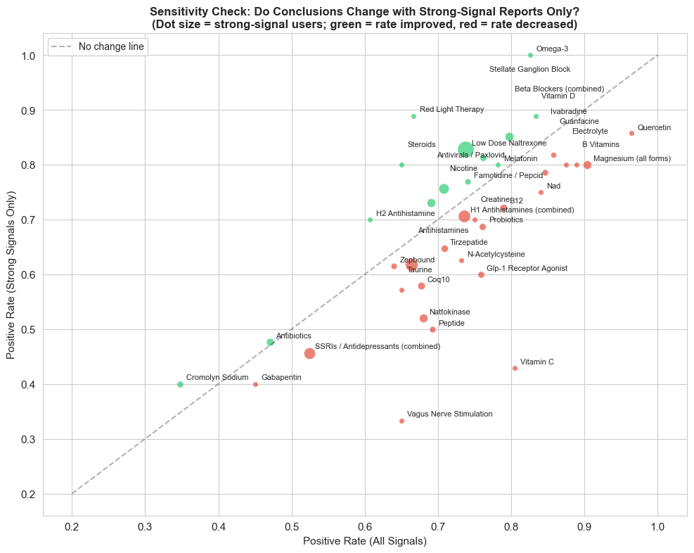

**Correlation between all-signal and strong-signal rankings:** r = 0.685. The main conclusions are fragile -- some treatments shift position when restricted to strong signals, suggesting the ranking is somewhat sensitive to signal quality.

## 9. Tiered Recommendations

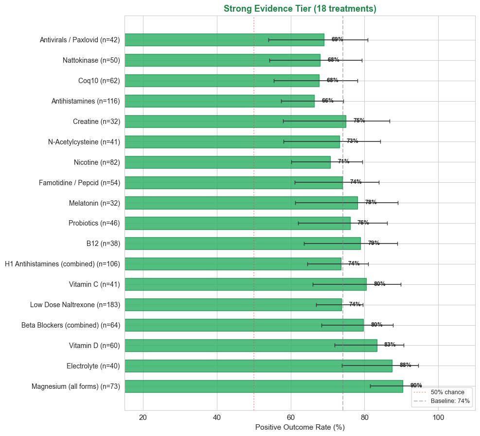

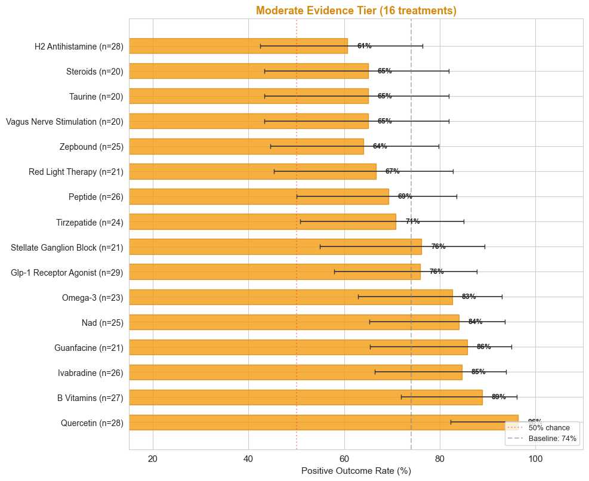

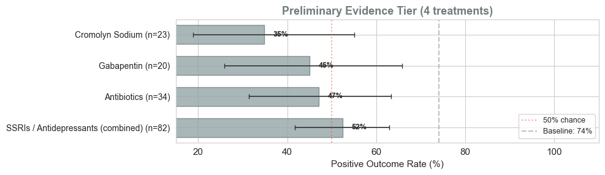

**Strong tier** treatments have large sample sizes and statistically significant positive outcomes. LDN stands out as the strongest overall recommendation -- high positive rate (74%) with the largest evidence base (n=183). Magnesium, vitamin D, electrolytes, and B12 are low-risk, accessible, and well-supported by this data.

**Note on SSRIs and cromolyn sodium:** These appear in the lower tiers not because they are definitively ineffective, but because this community's experience with them is mixed-to-negative. A patient with a clear clinical indication (diagnosed depression, confirmed MCAS) should discuss these with their doctor regardless of community sentiment.

## 10. Conclusion

Bottom Line

Out of 38 treatments with sufficient data, the Long COVID community on Reddit most consistently reports positive outcomes from **micronutrient supplementation** (magnesium, B vitamins, vitamin D, electrolytes, quercetin) and **low dose naltrexone (LDN)**. These are not fringe findings -- LDN alone has 183 user reports in one month, making it the most discussed treatment in the dataset.

A patient new to Long COVID, based on this data, should consider starting with **magnesium, electrolytes, and B vitamins** as low-risk, accessible, and well-supported first steps. **LDN** is the strongest single-agent recommendation for those who can access it (it requires a prescription and compounding pharmacy). **Nicotine patches** are an unconventional option generating real enthusiasm in this community, though they carry their own risks.

**SSRIs should be approached with caution** for Long COVID specifically. While they may help comorbid depression or anxiety, this community reports them as no better than chance for Long COVID symptoms overall. **Cromolyn sodium**, despite its theoretical appeal for MCAS, has the worst outcome profile in this dataset.

The most surprising finding is the magnitude of the gap between simple, cheap micronutrients and expensive prescription medications. This likely reflects a combination of factors: micronutrient deficiencies are genuinely common in Long COVID and respond well to correction; prescription medications are prescribed for more severe cases (confounding by indication); and community reporting favors accessible interventions. Regardless of the cause, the pattern is consistent and large enough to be clinically interesting.

## 11. Research Limitations

1. **Selection bias:** This data comes from r/covidlonghaulers on Reddit. Reddit users skew younger, more tech-savvy, and more engaged with self-advocacy than the general Long COVID population. Treatment preferences and outcomes may differ in populations not represented on Reddit.
2. **Reporting bias:** Users are more likely to post about treatments that produced a strong response (positive or negative) than treatments that did nothing. This inflates both tails and underrepresents null results. The 74% overall positive rate is a symptom of this bias.
3. **Survivorship bias:** Users who recovered fully may leave the community and stop posting. Users who are too ill to post are absent from the data. The "surviving" community members represent a middle band of severity -- not the best or worst outcomes.
4. **Recall bias:** Posts are written from memory. Users may misattribute improvements to the most recent treatment change, forget timing details, or conflate multiple treatments started simultaneously.
5. **Confounding:** Users taking LDN are likely also taking magnesium, B vitamins, and other supplements. We cannot isolate individual treatment effects from this observational data. The heatmap in Section 5 is hypothesis-generating, not causal.
6. **No control group:** There is no untreated comparison group. We compare treatments to each other and to a statistical baseline, but we cannot compare to "no treatment at all." Some positive outcomes may reflect natural disease trajectory, not treatment effect.
7. **Sentiment vs. efficacy:** NLP-extracted sentiment is a proxy for patient-reported outcomes, not a clinical measurement. A "positive" sentiment report could mean symptom reduction, hope about a new treatment, or simply a less negative experience than expected. We do not have biomarkers, functional assessments, or standardized outcome measures.
8. **Temporal snapshot:** One month of data (March 11 -- April 10, 2026) captures a snapshot, not a trend. Treatment popularity and outcomes may shift with new research, new products entering the market, or changes in community composition. The GLP-1 agonist discussion, for example, appears to be a recent trend that may or may not persist.

"These findings reflect reporting patterns in online communities, not population-level treatment effects. This is not medical advice."